# ReproducibleResearch

## Introduction

This is the course project for Reproducible Research. Below are the tasks and the code, which implements them.

## Loading and preprocessing the data

Read the data

```r
actData <- read.csv("activity.csv")
```

Aggregate total number of steps per day and plot the corresponding histogram

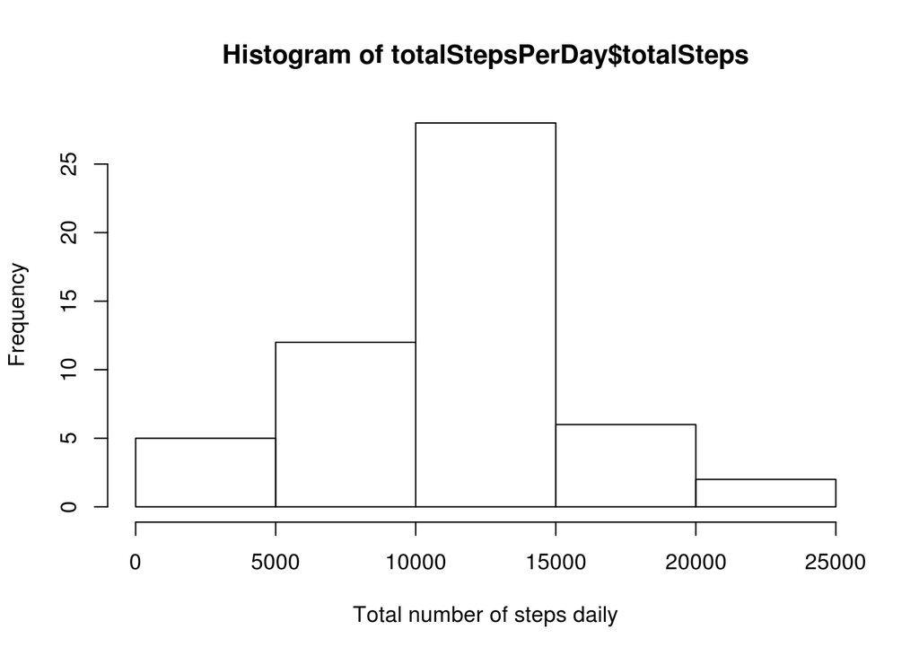

```r
totalStepsPerDay <- aggregate(actData$steps, by = list(actData$date), FUN = sum)
names(totalStepsPerDay) <- c("date","totalSteps")
hist(totalStepsPerDay$totalSteps, xlab = "Total number of steps daily")
```

Calculate the mean and the median per day

```r
meanStepsPerDay <-aggregate(actData$steps, by = list(actData$date), FUN = mean, na.rm=TRUE)
names(meanStepsPerDay) <- c("date", "steps")
medianStepsPerDay <- aggregate(actData$steps, by = list(actData$date), FUN = median, na.rm=TRUE)
names(medianStepsPerDay) <- c("date","steps")
```

Calculate the average daily activity pattern. Average the number of steps per interval

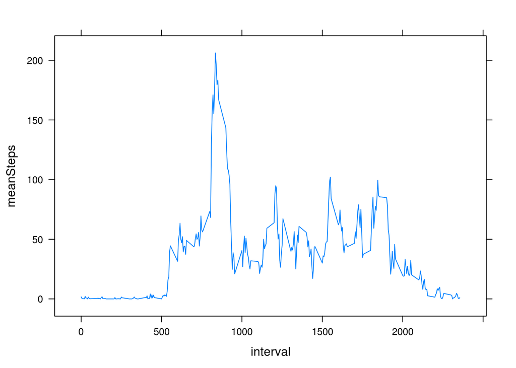

```r
intervalMeans <- aggregate(actData$steps, by = list(actData$interval), mean, na.rm = TRUE)
names(intervalMeans) <- c("interval","meanSteps")
library(lattice)
xyplot(data=intervalMeans, meanSteps ~ interval, type="l")
```

```r
intervalMeans[intervalMeans$steps == max(intervalMeans$steps),]
```

```
## [1] interval  meanSteps
## <0 rows> (or 0-length row.names)
```

## Imputing missing values

Calculate total number of missing values in the dataset

```r
length(which(is.na(actData)))
```

```
## [1] 2304
```

and impute the missing values belonging to a specific interval with the mean of this interval

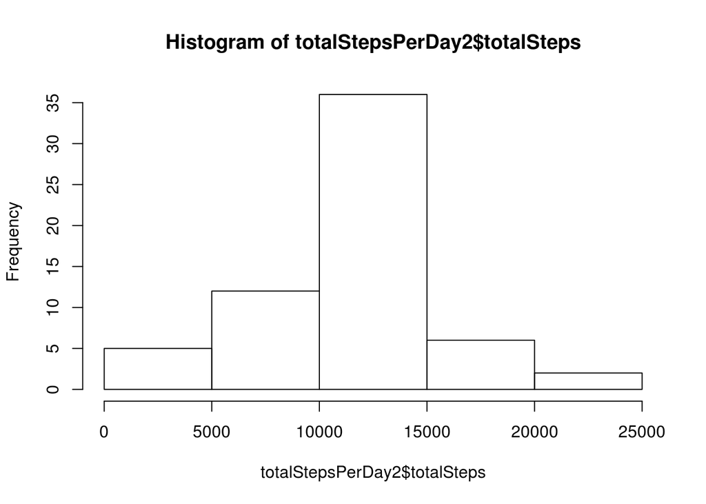

```r
actData$interval <- as.factor(actData$interval)

for (i in 1:nrow(actData)) {
  if (is.na(actData[i,"steps"])) {
    actData[i,"steps"] <- round(intervalMeans[intervalMeans$interval == actData[i,"interval"], "meanSteps"])
  }
}

totalStepsPerDay2 <- aggregate(actData$steps, by = list(actData$date), FUN = sum)
names(totalStepsPerDay2) <- c("date","totalSteps")
hist(totalStepsPerDay2$totalSteps)
```

```r
meanStepsPerDay2 <- aggregate(actData$steps, by = list(actData$date), FUN = mean)
names(meanStepsPerDay2) <- c("date","steps")
medianStepsPerDay2 <- aggregate(actData$steps, by = list(actData$date), FUN = median)
names(medianStepsPerDay2) <- c("date","steps")
```

The replacement of the NAs has caused no changes in the values of the median and the mean.Exception are the days, which included only NA values

```r
head(data.frame(meanStepsPerDay$date, meanStepsPerDay$steps,meanStepsPerDay2$steps))
```

```
##   meanStepsPerDay.date meanStepsPerDay.steps meanStepsPerDay2.steps
## 1           2012-10-01                   NaN               37.36806
## 2           2012-10-02               0.43750                0.43750
## 3           2012-10-03              39.41667               39.41667
## 4           2012-10-04              42.06944               42.06944
## 5           2012-10-05              46.15972               46.15972
## 6           2012-10-06              53.54167               53.54167
```

```r
head(data.frame(medianStepsPerDay$date, medianStepsPerDay$steps,medianStepsPerDay2$steps))
```

```
##   medianStepsPerDay.date medianStepsPerDay.steps medianStepsPerDay2.steps
## 1             2012-10-01                      NA                     34.5
## 2             2012-10-02                       0                      0.0
## 3             2012-10-03                       0                      0.0
## 4             2012-10-04                       0                      0.0
## 5             2012-10-05                       0                      0.0
## 6             2012-10-06                       0                      0.0
```

## Find differences between weekends and weekdays

In order to find activity patterns differences between weekdays and weekends:

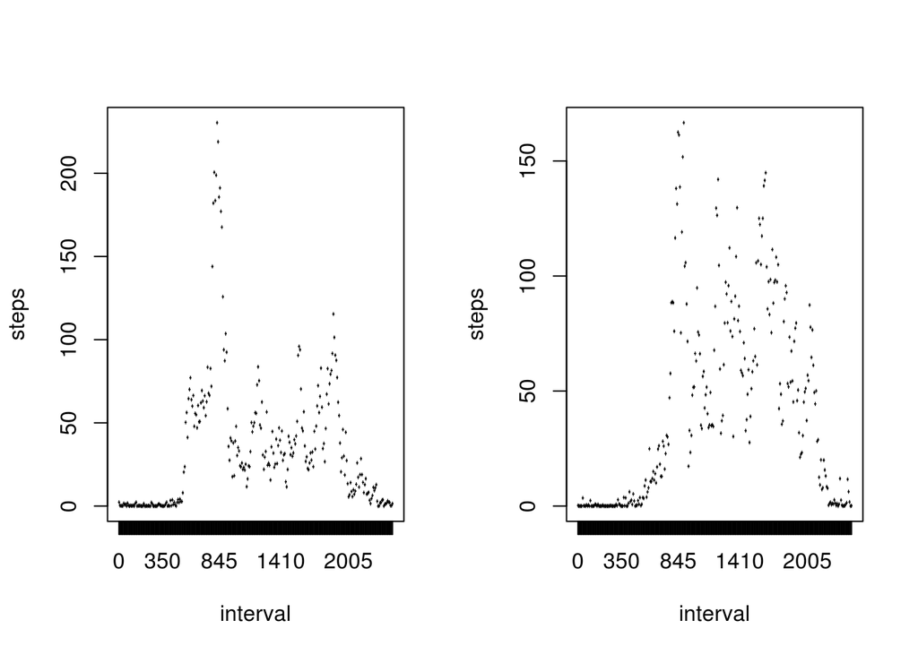

```r
weekdayFlag <- c()
for (i in 1:nrow(actData)) {
  day <- weekdays(as.POSIXct(actData[i,"date"]))
  if (day == "Samstag" | day == "Sonntag") {
    weekdayFlag <- append(weekdayFlag, "Weekend")
  } else {
    weekdayFlag <- append(weekdayFlag, "Weekday")
  }
}
actData$weekdayFlag <- as.factor(weekdayFlag)

meanStepsWeek <- aggregate(actData$steps, by = list(actData$interval,actData$weekdayFlag), FUN = mean)
names(meanStepsWeek) <- c("interval","weekdayFlag","steps")

par(mfcol=c(1,2))
#plot(data=meanStepsWeek[meanStepsWeek$weekdayFlag=="Weekday",], steps ~ interval, type="l", ylim=c(400))
#plot(data=meanStepsWeek[meanStepsWeek$weekdayFlag=="Weekend",], steps ~ interval, type="l", xaxt= "n" , ylim = c(400))
plot(data=meanStepsWeek[meanStepsWeek$weekdayFlag=="Weekday",], steps ~ interval, type="l")
plot(data=meanStepsWeek[meanStepsWeek$weekdayFlag=="Weekend",], steps ~ interval, type="l")
```